# PSTAT 174 Final Project: Time Series and Stock Price (SPX)

Kuan-I Lu, k_lu@ucsb.edu

2024-06-08

## Abstract

The stock market is one of the most commonly known existing financial markets. The history of stock market goes way back in time, emerging from early 1800s. As one may know, large indexes like S&P 500 (SPX) and Dow Jones Industrial Average (DJIA) are often good representations of the overall economic strength of a nation, in this case, the United States. Therefore, studying the data and discovering the trend of the price of some of the most well-known indexes would give us a good grasp and information on the overall financial and economic environment.

We also know that stock prices are not independently distributed. As economic grows over time, the stock price would also have an upward trend in the long run. With all these information, time series can be a good way to approach and understand the stock data. In this project, we will be applying some of the models taught in class to try to explain the time series data we have.

# 1. Introduction

I am very passionate and interested in the financial market, more specifically, the stock market. Stated in the book *A Random Walk Down Wall Street* by Burton Malkiel, the financial market is very much unpredictable and random, and the existing “methods” that can successfully predict the trend of stock prices are results of survivorship bias (Malkiel, 2019). The book suggested that the only golden rule of the stock market is that it’ll grow and get better in the long run. After learning about ways to explain data with the tool of time series analysis, I want to put real-life data to test and see if the selected models can explain the stock price data well or not.

Numerous past studies have been conducted to break down the underlying trend of the stock market, and this project is just a mere attempt to put what have been taught in this course into practice. For the purpose of this project, I will be utilizing the SARIMA model and the ARCH/GARCH model.

# 2. Data

## 2.1. Introducing the Data

The data includes the index closing price of some of the largest indexes around the world from 1994 to 2021. Here we’re focusing on the price of SPX over time. The frequency of the data is daily, but for better interpretation and due to the nature of the weekday-only structure, we will transform the data frequency into monthly in the data cleaning process. The values of the data are in US dollars, which are the closing price each day. After transforming the frequency, the values would be the average price in US dollars, monthly. This data set is important because if we can find the trend or the underlying model of SPX price, which is a good representation of the economy, we can potentially also find the structure and trend of the financial market or even the entire economic environment. The data set is downloaded from Kaggle and more information of the data can be found [here](https://www.kaggle.com/datasets/omkarborikar/closing-price-of-indexes-time-series-data).

## 2.2. Cleaning the Data

The data set only records value of all weekdays(trading days) and there is no data available for weekends. For better interpretation and a more general prediction, we focus on the monthly average of the index values rather than the daily data.

After cleaning the data, we are left with a time series with 334 observations, which is sufficient for the purpose of this project. We will continue to use the monthly data for the rest of this project.

# 3. Methodology

In this project, we are going to apply to models to try to explain our SPX price time series data. The two methods are the SARIMA model and the ARCH/GARCH model.

## 3.1. SARIMA Model

The SARIMA model $(p,d,q)\times(P,D,Q)$ is an extended version of the ARIMA model by combining both non-seasonal and seasonal components to help capture the structure and pattern in time series data effectively. In the non-seasonal part $(p,d,q)$, we have three parameters: $p$ which denotes the order of autoregressive part; $d$ which represents the degree of differencing needed for stationarity; and $q$ representing the order of moving average. Similarly, the seasonal portion $(P,D,Q)$ has these same features but with additional notations $S$ indicating the length of cycle for seasonality. SARIMA models are capable of understanding complicated seasonality using the same autoregressive and moving average idea as an ARIMA model.

## 3.2. ARCH/GARCH Model

The ARCH/GARCH model is a statistical model taking the time varying volatility into account, and is particularly useful with financial time series data. The main idea of ARCH/GARCH model is to capture the trend of the volatility by clustering based on the correlation in variance/squared residuals, meaning that periods of high variance are often followed by high variance data, and same for low variance periods. ARCH/GARCH model can be viewed as an extension of the ARMA model. While the ARMA model assumes constant variance, the ARCH/GARCH model introduces a conditional variance equation. This equation models the current period’s variance as a function of past squared residuals and past variances, allowing the model to dynamically adjust volatility over time. Instead of just using the ARCH/GARCH model, we often use ARMA()-GARCH() model, with the coefficients in ARMA() implying the structure of the mean and the coefficients in GARCH() implying the structure of the variance, which also follows an ARMA() process.

# 4. Results

## 4.1. Results from SARIMA

### 4.1.1. Transforming the Data

Let’s first look at the time graph, ACF, and PACF of our original data:

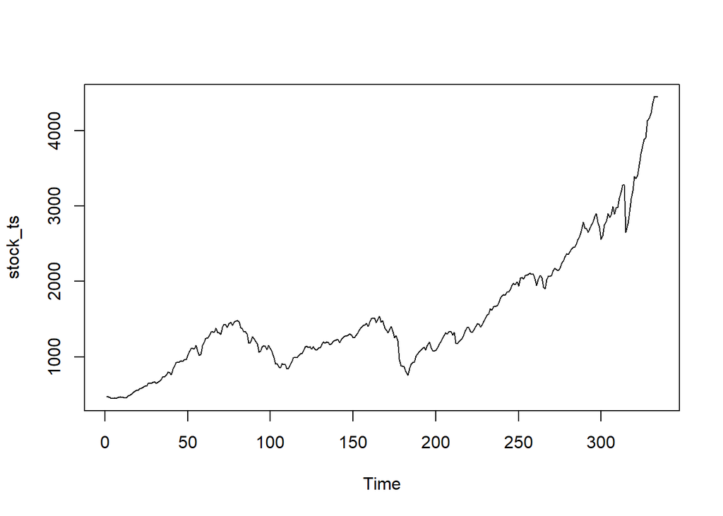

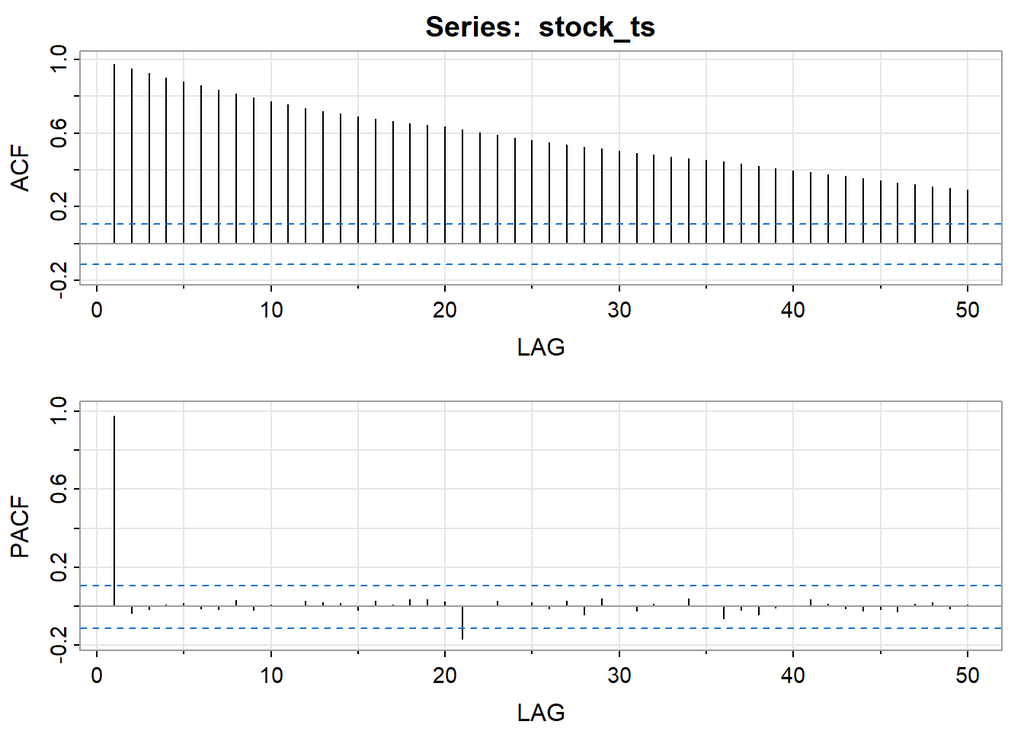

Observe that though with fluctuations, the data generally follows an upward trend, with the slope getting larger as time moves on. We will try to accommodate this phonomenon by taking log transformation and differencing the data in the next few steps.

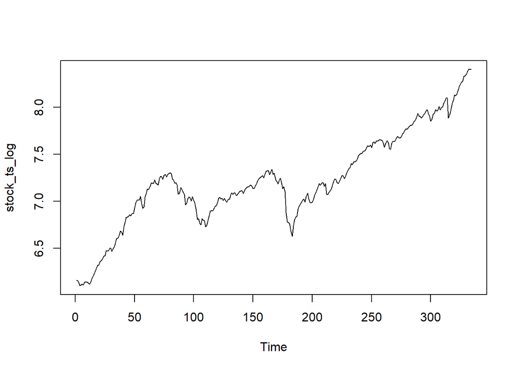

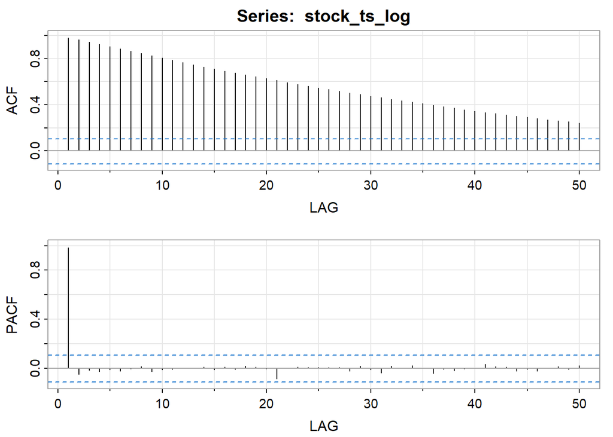

After we take the log of the data, we can see that the growth, though still exists, has become less drastic and happened on a smaller scale. Also, the slow decay in ACF is an indication that differencing may be needed. Let’s take the first difference to see how the data behaves and it’s properties.

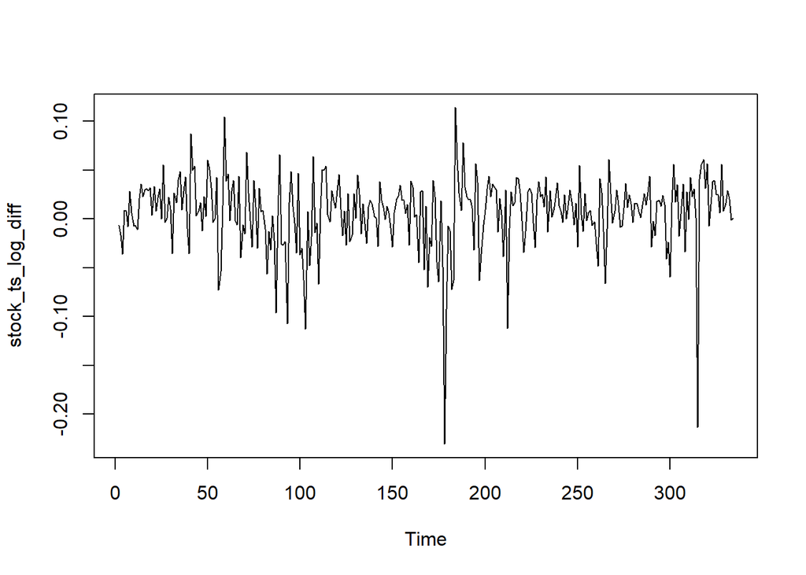

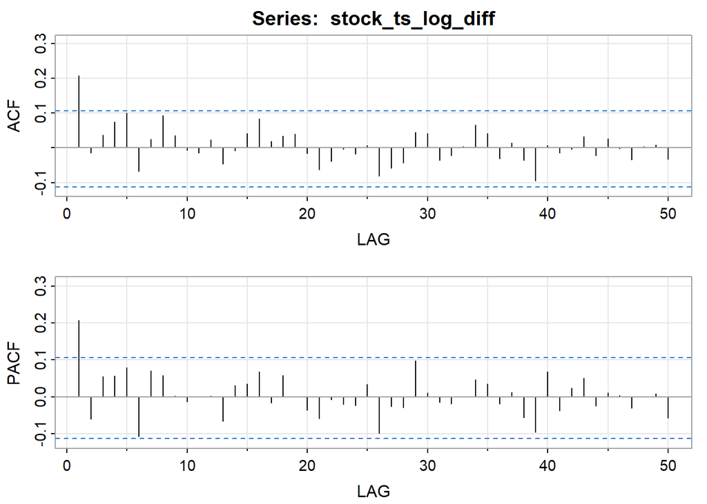

After we take the first difference, we can see that the data set behaves more like a stationary time series, suggesting d = 1. Instead of the price of the SPX index, the data we obtained now is the return rate of the data, with return rate $y_t = \nabla log(x_t)$, $x_t$ being the monthly price of the SPX index.

### 4.1.2. Selecting and Fitting Models

Looking at the ACF and PACF graph of the log difference of SPX price, notice that both the ACF and PACF cut off after lag 1. With this observation, we can try to fit our return rate into all three AR(1), MA(1), ARMA(1, 1) model to see if these models do well at explaining the underlying structure of the data. (In other words, fitting the log price into ARIMA(1, 1, 0), ARIMA(0, 1, 1) and ARIMA(1, 1, 1)).

Moreover, though not distinct, there seemed to also be a seasonal pattern from observation of the ACF and PACF plot. This observation suggests to fit a SMA(1) with $S = 6$, which is an ARIMA$(0, 0, 1) \times(0, 0, 1)_6$ model for the log difference. Here we fit the model and compare the performances.

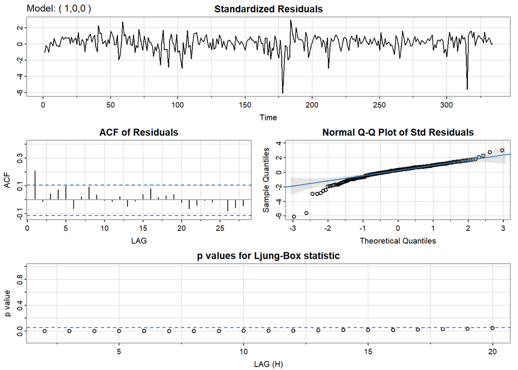

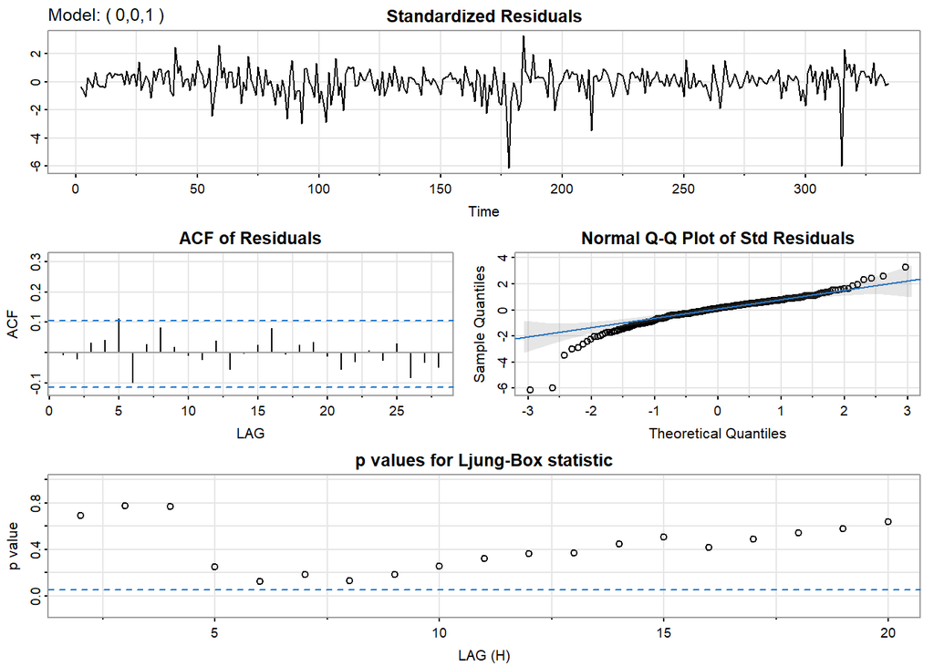

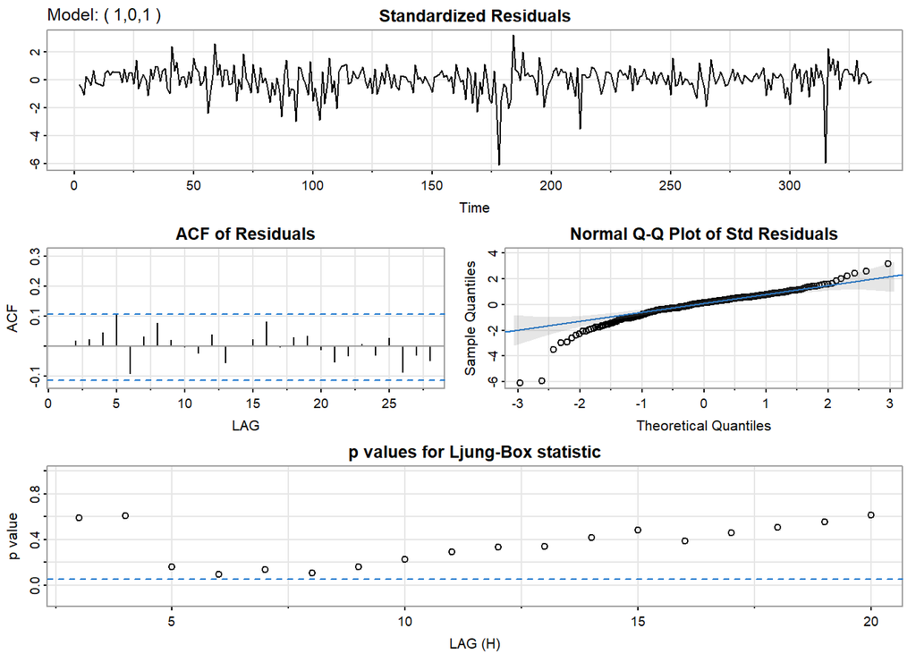

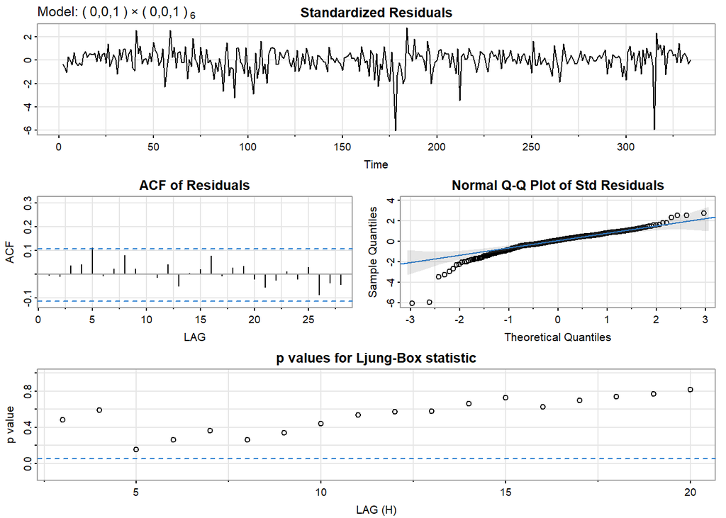

After fitting our model in to the four ARIMA models, we can see that none of the models explains the data perfectly. The residuals for all four models fail to behave like white noises in the Q-Q plot. However, let’s still select the best one out of the four models. First we eliminate both ARMA(1, 1) and ARMA$(0, 0, 1) \times(0, 0, 1)_6$ because the coefficients are not significant. Then, since the MA(1) model has a slightly lower AIC, -3.7740, we choose to use MA(1) to explain our data.

Diagnosing the fit of the MA(1) model, the model estimated significant coefficients `ma1` = 0.2283 and `xmean` = 0.0067. The time plot of the standardized residuals shows no obvious patterns, even though with the presence of some outliers reaching over 6 standard deviations in magnitude. The ACF of the standardized residuals matches the model assumptions. However, the normal Q-Q plot rejects the normal assumption, with too many values being outside of the confidence interval. With this observation, the model doesn’t fit entirely well to the data. Moving on, we will make forecasts with the MA(1) model for the log difference of price (ARIMA(0, 1, 1) for the log price).

### 4.1.3. Forecasting

Since we are more interested in the actual price rather than the growth rate of the data, we will fit and make forecast of the next 12 months of the log price, `stock_ts_log`, using the ARIMA(0, 1, 1) model.

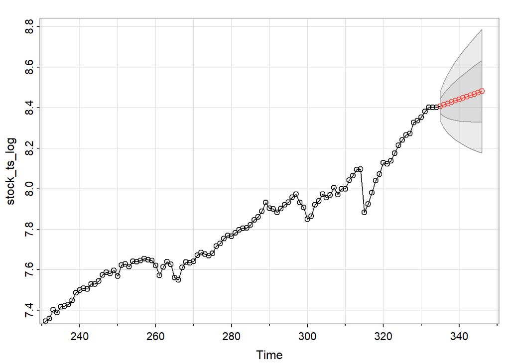

## 4.2. Results from ARCH/GARCH

### 4.2.1. Obersving Hints of GARCH Model

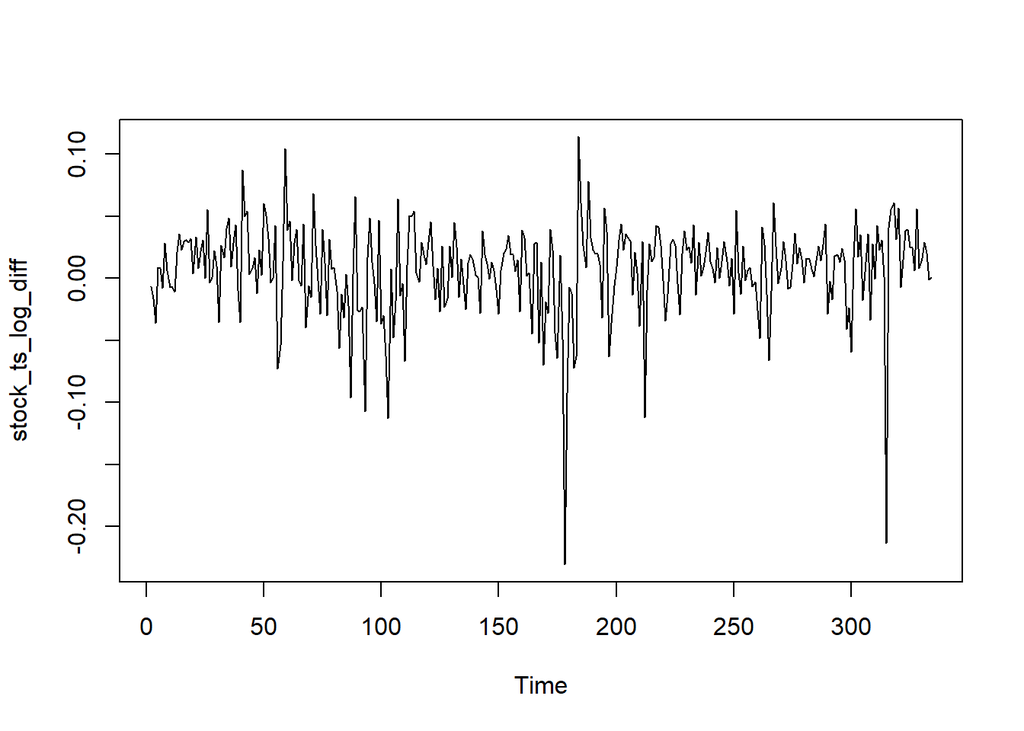

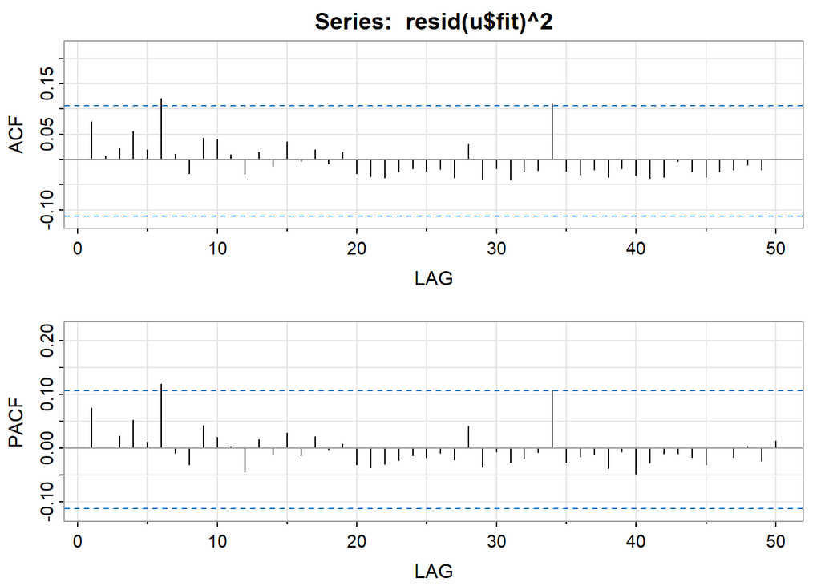

### 4.2.2. Selecting and Fitting Models

Here we fit different GARCH($p, q$) models to try to capture the dependence of residuals. Let’s try GARCH(1, 0) and GARCH(1, 1). Note that we want to avoid parameters too large to prevent overfitting.

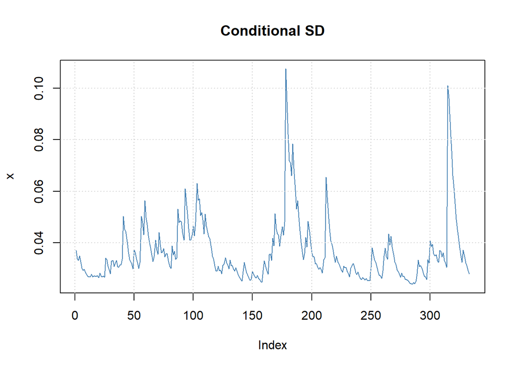

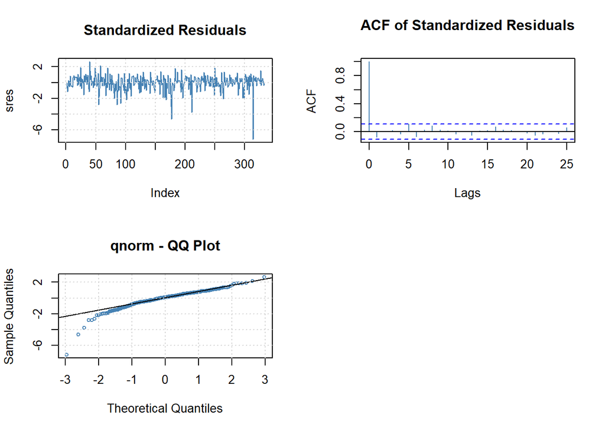

### 4.2.3. Assessing Performance

GARCH model us essentially an improvement from the ARMA model. Indeed, comparing the AIC of our best ARMA model to out best ARCH-GARCH model, we can see an improvement of AIC from -3.7740 to -3.8358. This improvement is due to us taking the heteroscedasticity of our time series into account and explained the volatility with our GARCH model.

# 5. Conclusion and Future Study

In this project, we have fitted our SPX price time series data using both SARIMA model and the extension of it, the MA()-GARCH() model, to try to capture the trend and the underlying structure of the data. As a result of tuning with multiple parameter values, our best performing model is the MA(1)-GARCH(1, 1) model. We have explained the data to a good extend, but the residuals of the fit has yet to behave like a white noise perfectly. However, I would still say that the model is a good fit. This is because we know there have been events that are outliers which are hard to predict and has had major impacts not only on the financial market, but around the whole world. Examples of these events are the financial crisis around 2008, and the global pandemic around 2020. Though we cannot predict these events, once these event happened, our GARCH model suggested that the variance of the data is going to be staying high for a while, indicating less stability.

Moving on with future improvements of this project. I believe that there exist more advanced methods and models to better explain time series data since the model we implemented in this project is rather simple. With simple model and structure it could be hard to capture and explain the more complicated trend found in real life data. In the future, I plan to explore more models that can be used to explain financial data, to see if I can make another improvement in terms of normality of residuals. I will also try to extend my knowledge to the modern era of time series as I am aware that the model used in this project have been existing for several decades and new discoveries have been made throughout the years. Perhaps I can find a method making predictions with better resolution which predicts a clear pattern with smaller variance rather than just an overall slope. Overall, I am glad that I get to use this project as a gateway into the realm of time series analysis. Prof. Ichiba’s guidance and navigation along the way really smooths out the bump in this journey. I am excited to learn more about time series in the future and to come back to make improvements of this project.

## Reference

Shumway, R. H., & Stoffer, D. S. (2017). *Time series analysis and its applications: With R examples* (4th ed.). Springer. p.75-p.153, p.253-p.262

Malkiel, B. G. (2019). *A random walk down Wall Street: The time-tested strategy for successful investing* (12th ed.). W. W. Norton & Company.

Omkar Borikar. 2021. Closing price of Top Indexes, Time Series Data [Data Set]. Kaggle. [link here](https://www.kaggle.com/datasets/omkarborikar/closing-price-of-indexes-time-series-data)

## Appendix

Here are some notable code and responses used in this project:

```r
#cleaning and transforming the data

#select only the price of spx to work with
stock_spx = stock %>%
  select(Date, spx) %>%
  mutate(Date = ymd(Date)) %>%
  arrange(Date)

#transform the data set so that it only contains monthly price of spx
stock_spx = stock_spx %>%
  mutate(Date_monthly = format(Date, "%Y-%m")) %>%
  group_by(Date_monthly) %>%
  mutate(spx_monthly = mean(spx)) %>%
  distinct(Date_monthly, spx_monthly, .keep_all = FALSE)

#extract the spx_monthly column as our time series data
stock_ts = ts(stock_spx$spx_monthly)
```

```
##
## Title:
##  GARCH Modelling
##
## Call:
##  garchFit(formula = ~arma(0, 1) + garch(1, 0), data = stock_ts_log_diff)
##
## Mean and Variance Equation:
##  data ~ arma(0, 1) + garch(1, 0)
## <environment: 0x0000016dfe33abe8>
##  [data = stock_ts_log_diff]
##
## Conditional Distribution:
##  norm
##
## Coefficient(s):
##        mu        ma1      omega     alpha1
## 0.0093883  0.2562299  0.0010075  0.3126316
##
## Std. Errors:
##  based on Hessian
##
## Error Analysis:
##         Estimate  Std. Error  t value Pr(>|t|)
## mu     0.0093883   0.0023911    3.926 8.63e-05 ***
## ma1    0.2562299   0.0637311    4.020 5.81e-05 ***
## omega  0.0010075   0.0001182    8.520  < 2e-16 ***
## alpha1 0.3126316   0.1360030    2.299   0.0215 *
## ---
## Signif. codes:  0 '***' 0.001 '**' 0.01 '*' 0.05 '.' 0.1 ' ' 1
##
## Log Likelihood:
##  637.3403    normalized:  1.913935
##
## Description:
##  Tue Aug 13 20:49:53 2024 by user: user
##
##
## Standardised Residuals Tests:
##                                   Statistic      p-Value
##  Jarque-Bera Test   R    Chi^2  815.4534127 0.000000e+00
##  Shapiro-Wilk Test  R    W        0.9122404 5.132589e-13
##  Ljung-Box Test     R    Q(10)    9.5052875 4.849125e-01
##  Ljung-Box Test     R    Q(15)   11.5958324 7.093277e-01
##  Ljung-Box Test     R    Q(20)   15.5940299 7.414690e-01
##  Ljung-Box Test     R^2  Q(10)    2.5555597 9.900411e-01
##  Ljung-Box Test     R^2  Q(15)    5.2404684 9.898872e-01
##  Ljung-Box Test     R^2  Q(20)    5.8304108 9.991079e-01
##  LM Arch Test       R    TR^2     2.6749918 9.974360e-01
##
## Information Criterion Statistics:
##       AIC       BIC       SIC      HQIC
## -3.803846 -3.758102 -3.804130 -3.785605
```

```
##
## Title:
##  GARCH Modelling
##
## Call:
##  garchFit(formula = ~arma(0, 1) + garch(1, 1), data = stock_ts_log_diff)
##
## Mean and Variance Equation:
##  data ~ arma(0, 1) + garch(1, 1)
## <environment: 0x0000016dfeda6300>
##  [data = stock_ts_log_diff]
##
## Conditional Distribution:
##  norm
##
## Coefficient(s):
##         mu         ma1       omega      alpha1       beta1
## 0.00838980  0.26346992  0.00013492  0.19776783  0.73447455
##
## Std. Errors:
##  based on Hessian
##
## Error Analysis:
##         Estimate  Std. Error  t value Pr(>|t|)
## mu     8.390e-03   2.217e-03    3.785 0.000154 ***
## ma1    2.635e-01   7.427e-02    3.548 0.000389 ***
## omega  1.349e-04   7.523e-05    1.793 0.072895 .
## alpha1 1.978e-01   8.143e-02    2.429 0.015153 *
## beta1  7.345e-01   8.718e-02    8.425  < 2e-16 ***
## ---
## Signif. codes:  0 '***' 0.001 '**' 0.01 '*' 0.05 '.' 0.1 ' ' 1
##
## Log Likelihood:
##  643.6618    normalized:  1.932918
##
## Description:
##  Tue Aug 13 20:49:54 2024 by user: user
##
##
## Standardised Residuals Tests:
##                                    Statistic      p-Value
##  Jarque-Bera Test   R    Chi^2  1250.4610354 0.000000e+00
##  Shapiro-Wilk Test  R    W         0.9004123 5.631418e-14
##  Ljung-Box Test     R    Q(10)    10.8321868 3.707409e-01
##  Ljung-Box Test     R    Q(15)    12.3383899 6.532560e-01
##  Ljung-Box Test     R    Q(20)    14.7195311 7.922248e-01
##  Ljung-Box Test     R^2  Q(10)     0.8920753 9.998983e-01
##  Ljung-Box Test     R^2  Q(15)     2.8352372 9.997173e-01
##  Ljung-Box Test     R^2  Q(20)     3.9333710 9.999595e-01
##  LM Arch Test       R    TR^2      1.4743859 9.998810e-01
##
## Information Criterion Statistics:
##       AIC       BIC       SIC      HQIC
## -3.835806 -3.778627 -3.836248 -3.813006
```